# Analysis of Spotify data

## Stacked barplots based on Succesfulness

The stacked barplot is a way of plotting the categorical values with regards to succesfulness of a song.

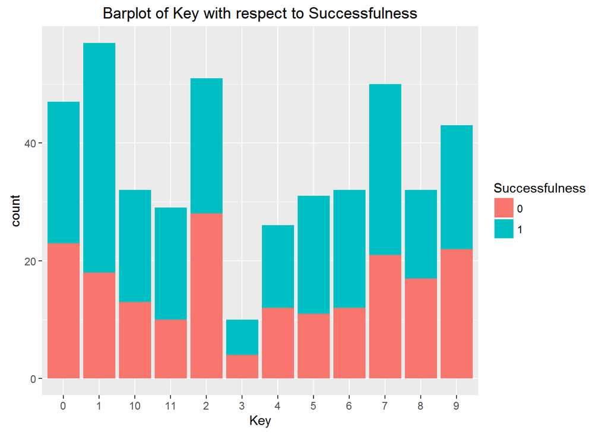

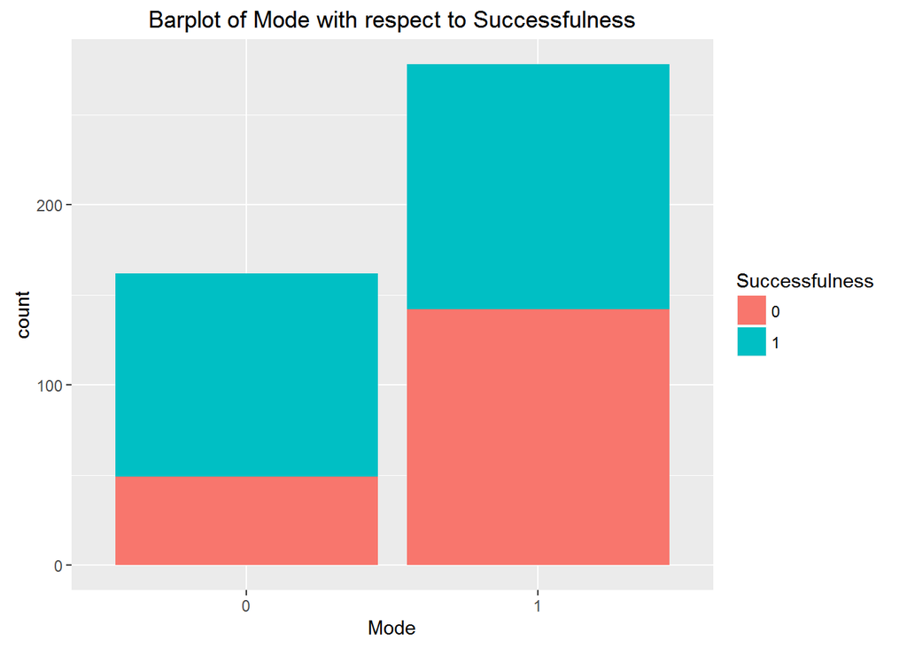

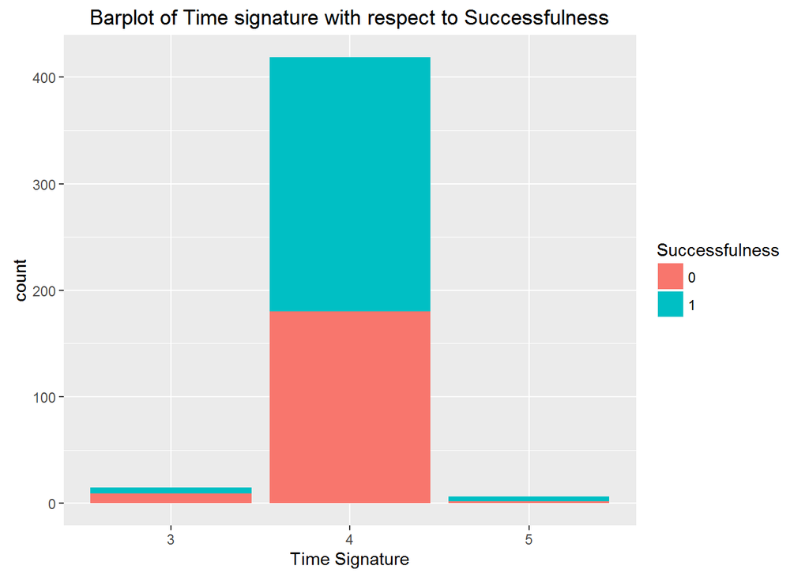

2. The time signature for most of the songs are 4.

## Pairwise Analysis on Audio features

The pairwise analysis is done based on comparison of two audio features and bringing out the relationship between them. Here the pariwise analysis of speechiness and acousticness; energy and valence; danceability and tempo and peak and successfulness are plotted.

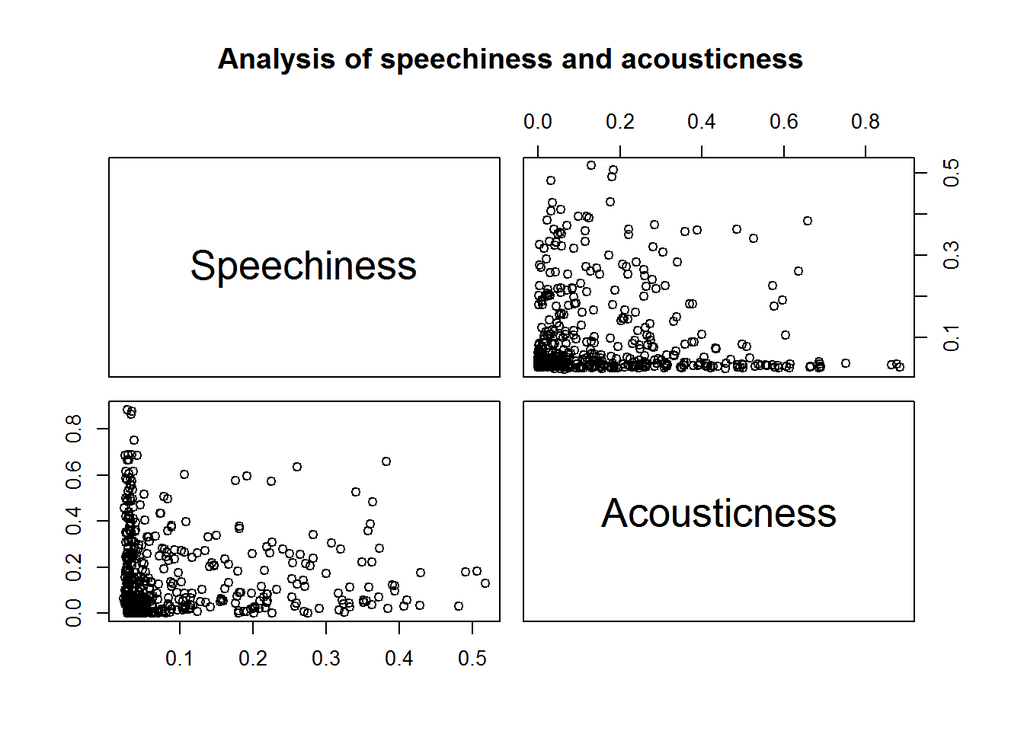

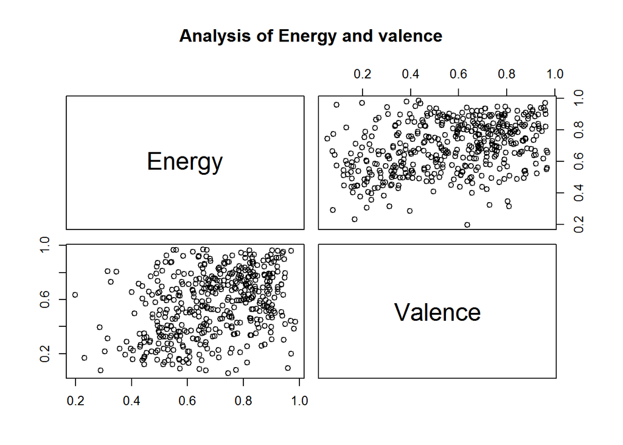

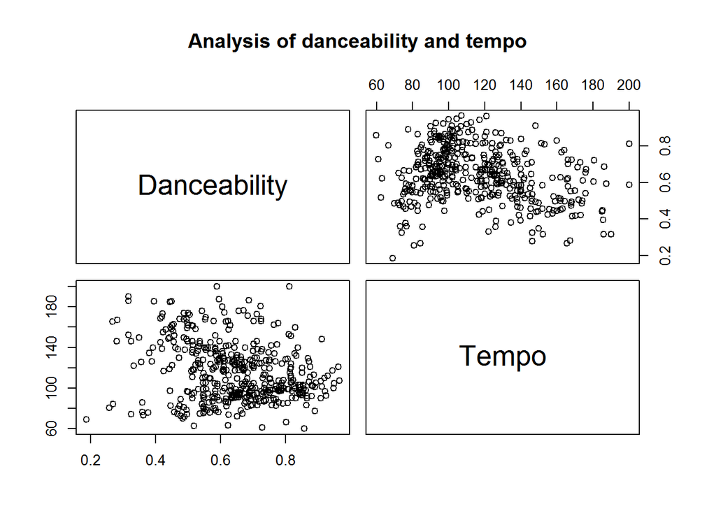

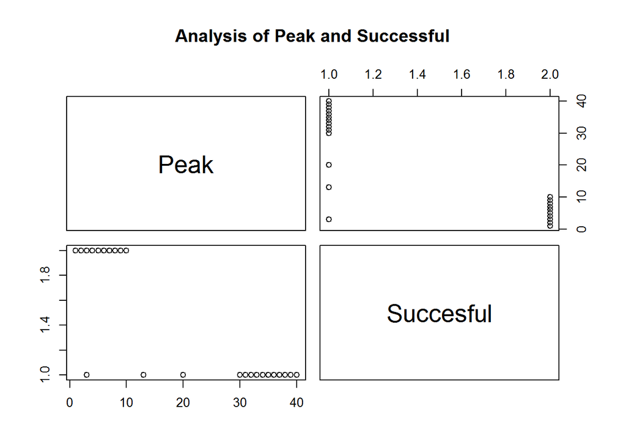

Inferences: 1. The speechiness and acousticness are similar in points being plotted. Most of the songs have speechiness and acousticness less than 0.1 and gradually spreads out at 0.1,0.2 and 0.3.

## Prediction of Successfulness of songs

The successfulness of the songs cn be predicted as supervised learning i.e classification. In Classification, the songs are classified using labels, ‘0’ which denotes unsuccessful and ‘1’ which denotes successful. One part of the song dataset is trained according to the classification models and the other part of the data set acts as test dataset. By the method of cross validation and classification models, prediction of successful and unsuccesful songs are made.

```r
#install.packages("rplot.part")
library(rpart.plot)
#install.packages("ROCR")
library(ROCR)
#install.packages("e1071")
library(e1071)
library(class)
```

## Decision tree

The decision tree is one of the classification model which partitions data according to class. This supervised learning model uses recursive partioning function which partitions the succesfulness of the song recursively according to its features. The decision tree can also be pruned to avoid overfitting the dataset and can be shown.

The decision tree partions from the root node which can be any of the features of the song to branch out leaf nodes according to yes/no condition. For example, in the songs dataset, the audio feature, Danceability is the root node which partions itself based on succesfulness of the song i.e if the Danceability is less or greater than 0.68, it branches out into two leaf nodes based on the condition.

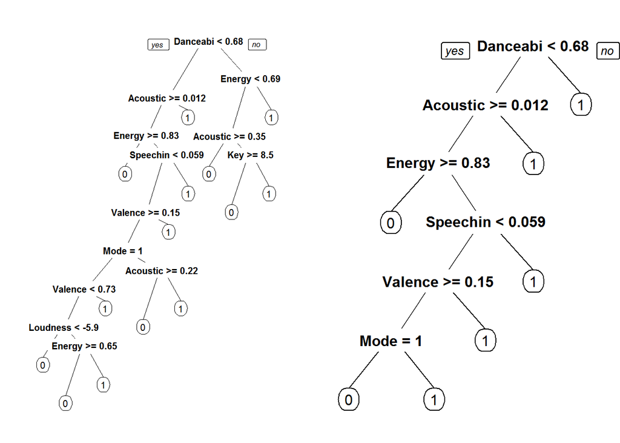

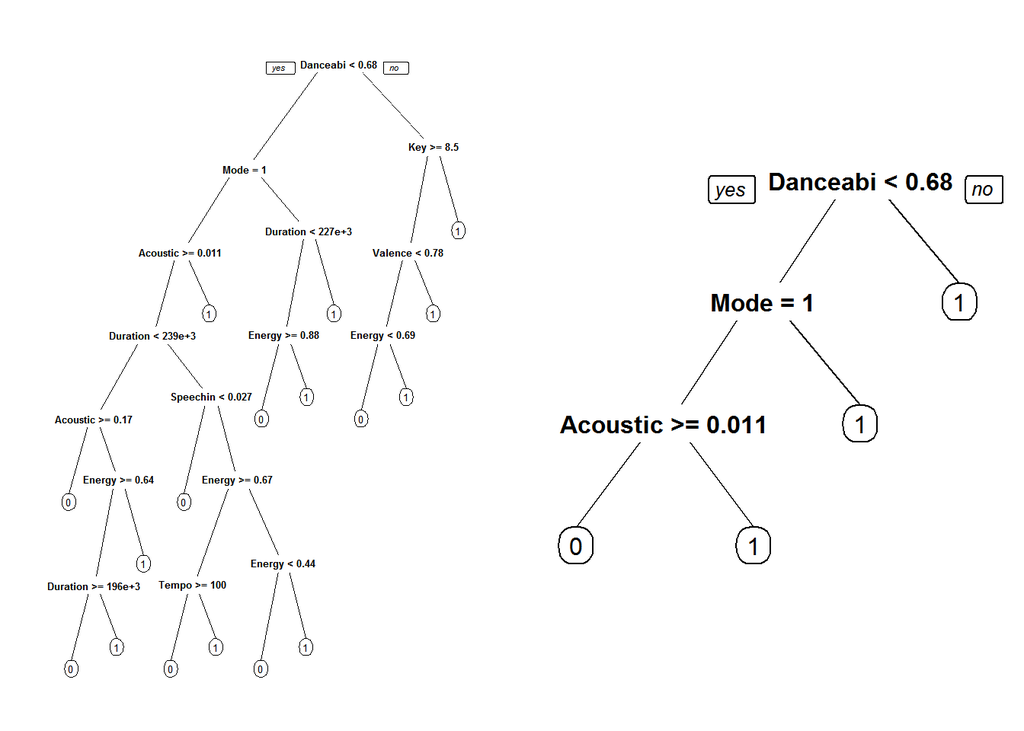

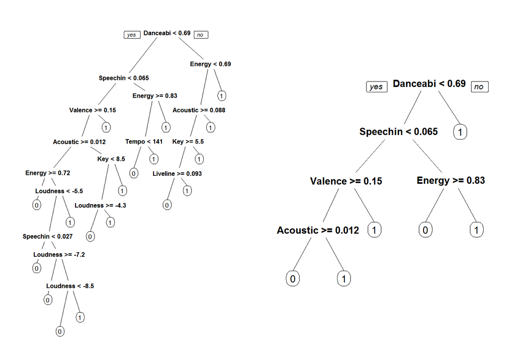

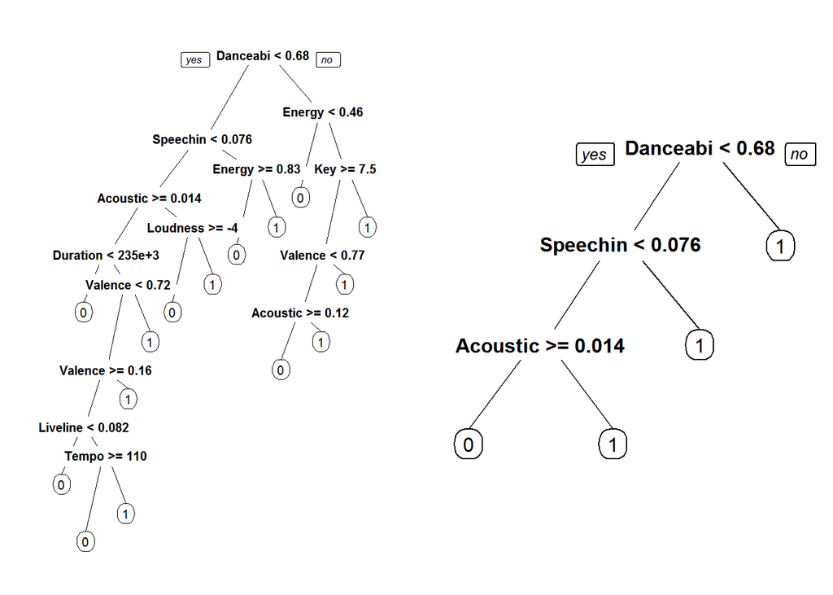

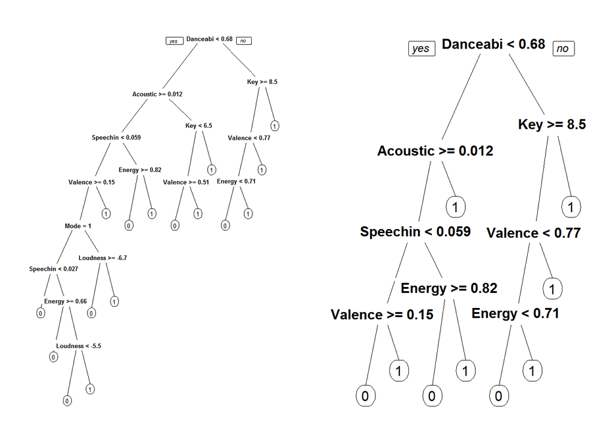

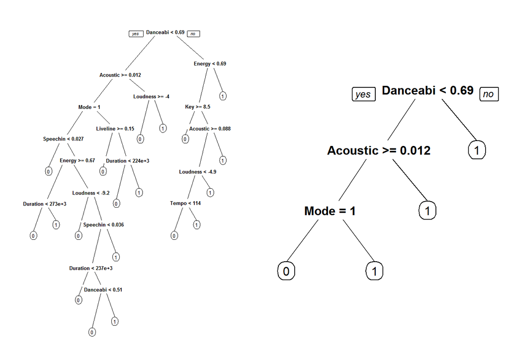

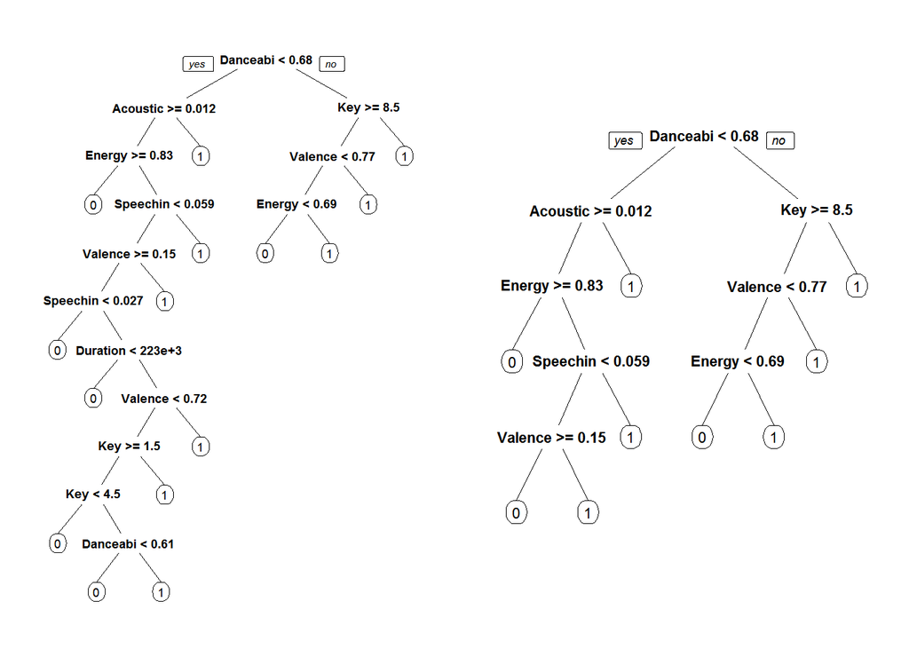

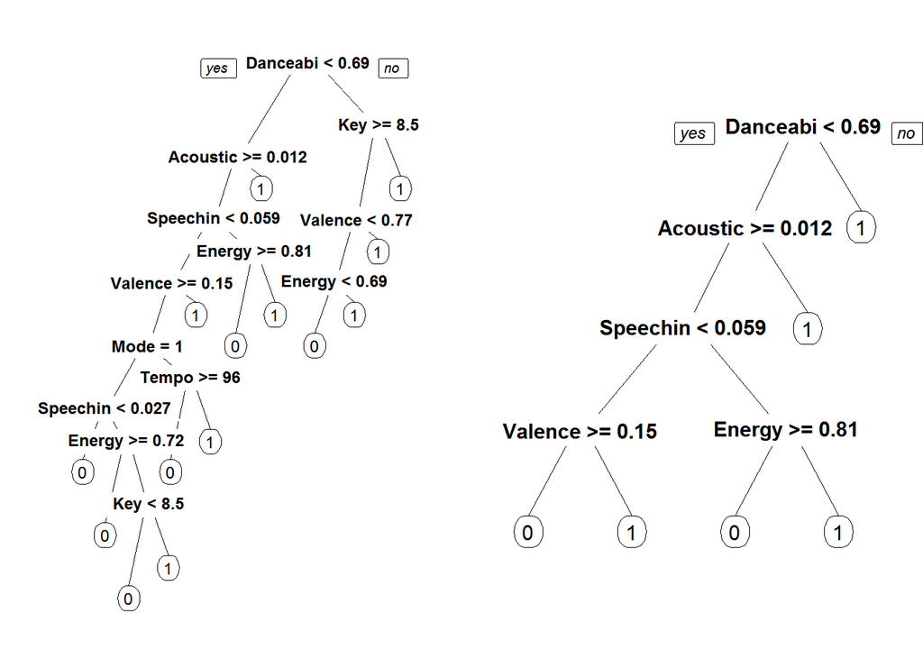

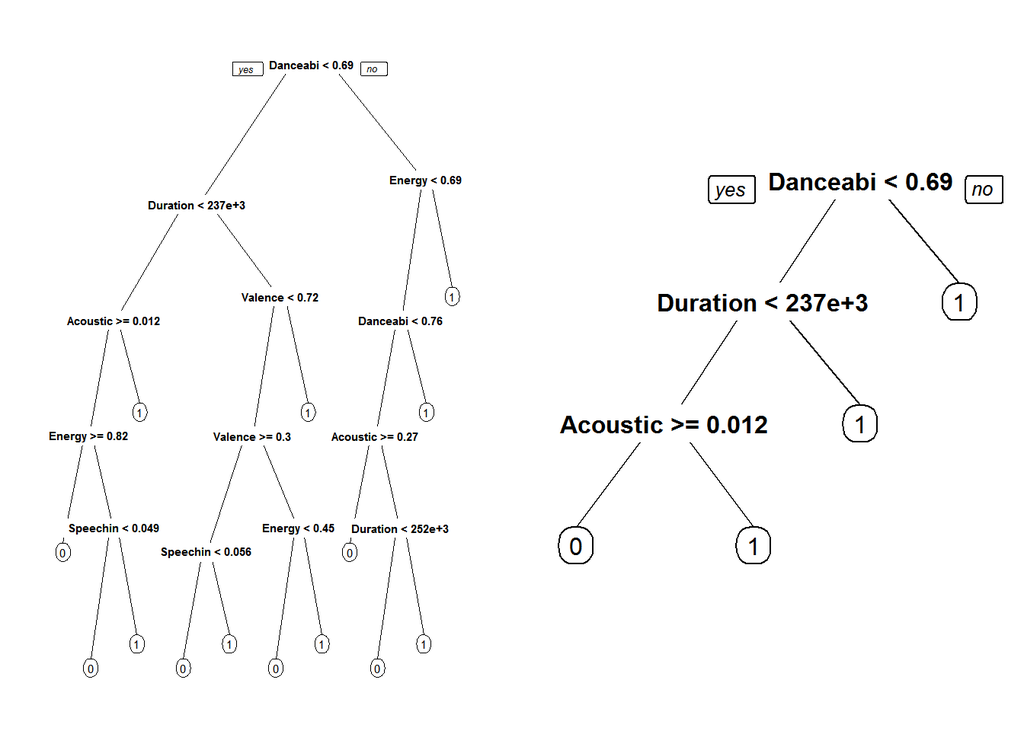

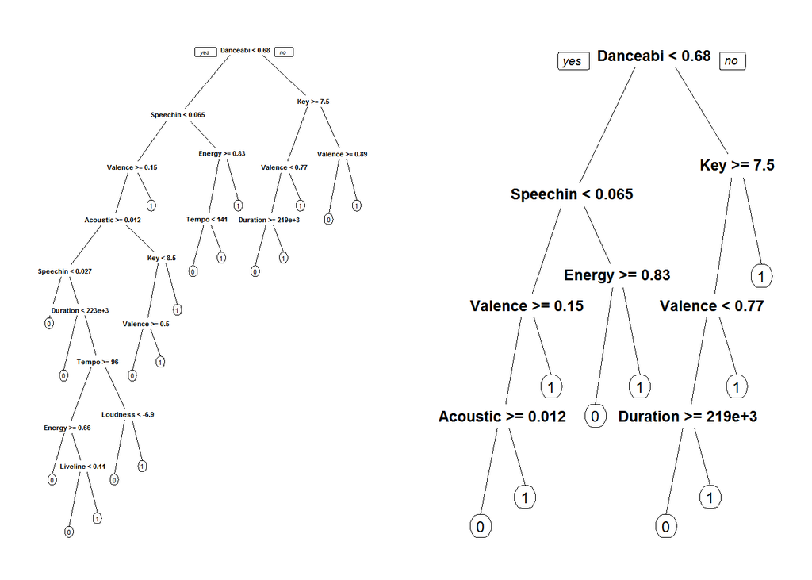

```
## [1] 0.6613636
```

```r
dtree <- function(x){
       n <- nrow(songs)
shuffled <- songs[sample(n),]
set.seed(1)
accs <- rep(0,x)
for (i in 1:x)
{
        indices <- (((i-1) * round((1/x)*nrow(shuffled))) + 1):((i*round((1/x) * nrow(shuffled))))
        train <- shuffled[-indices,]
        test <- shuffled[indices,]
        tree <- rpart(Successfulness ~ Danceability+Energy+Key+Loudness+Mode+Speechiness+Acousticness+Instrumentalness+Liveliness+Valence+Tempo+Duration+TimeSignature, train, method = "class")
        pred <- predict(tree,test,type="class")
        conf <- table(test$Successfulness,pred)
        accs[i] <- sum(diag(conf))/sum(conf)
        accs[i]
        par(mfrow=c(1,2))
        prp(tree)
        pruned <- prune(tree,cp=tree$cptable[which.min(tree$cptable[,"xerror"]),"CP"])
        prp(pruned)
}
mean(accs)
}
dtree(10)
```

## K Nearest Neighbours

K Nearest Neighbour is another classification model which predicts the test song based on the Kth nearest neighbour(Euclidean Distance) from the training dataset. Based on K values, the Euclidean distance of test dataset is measured from the K nearest neighbours of training dataset and classified as Successful or unsuccessful accordingly. The audio features are normalized to fit the scale and avoid Scaling issue. Here the Kvalue is determined by a certain range of values with regards to training dataset. The k value with the highest accuracy (as shown in plots) is taken for every iteration (cross validation) and the accuracies are found out for every iteration. The mean of accuracy is calculated.

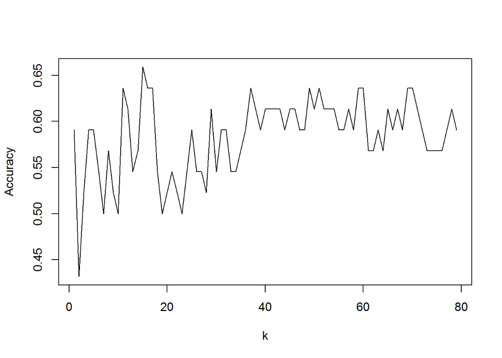

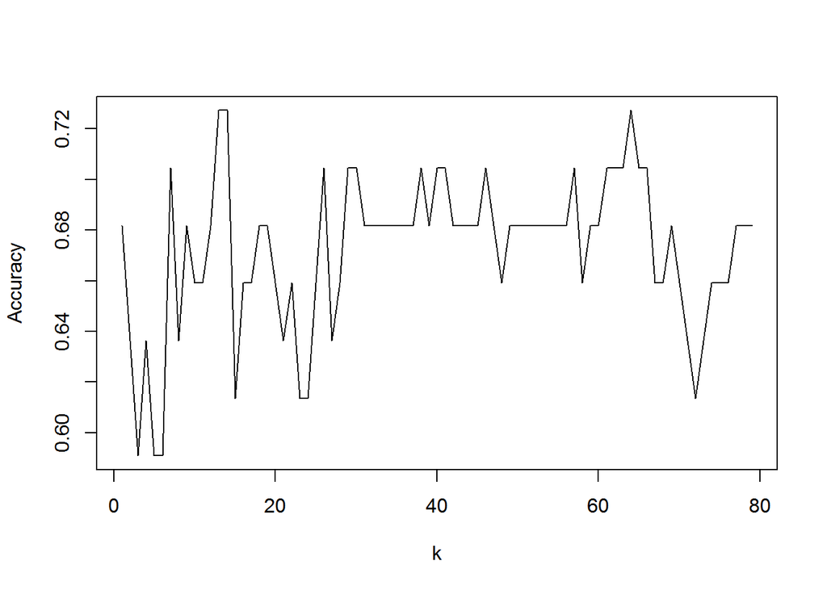

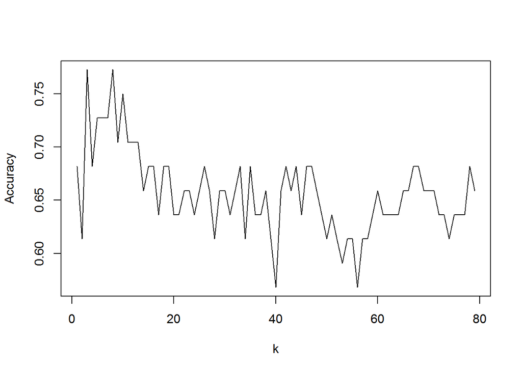

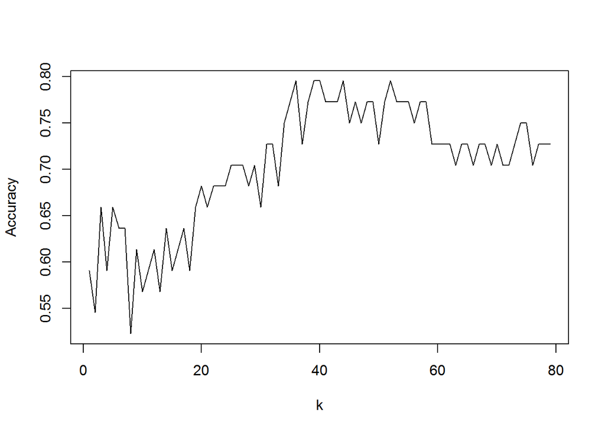

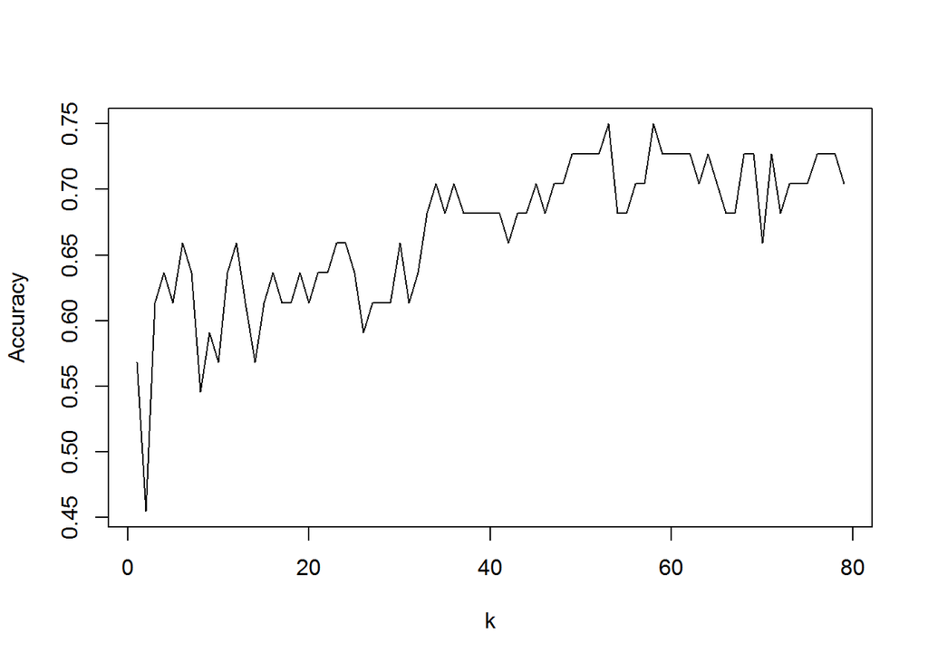

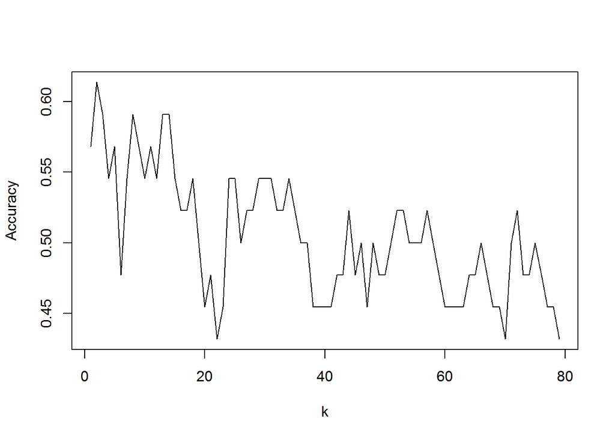

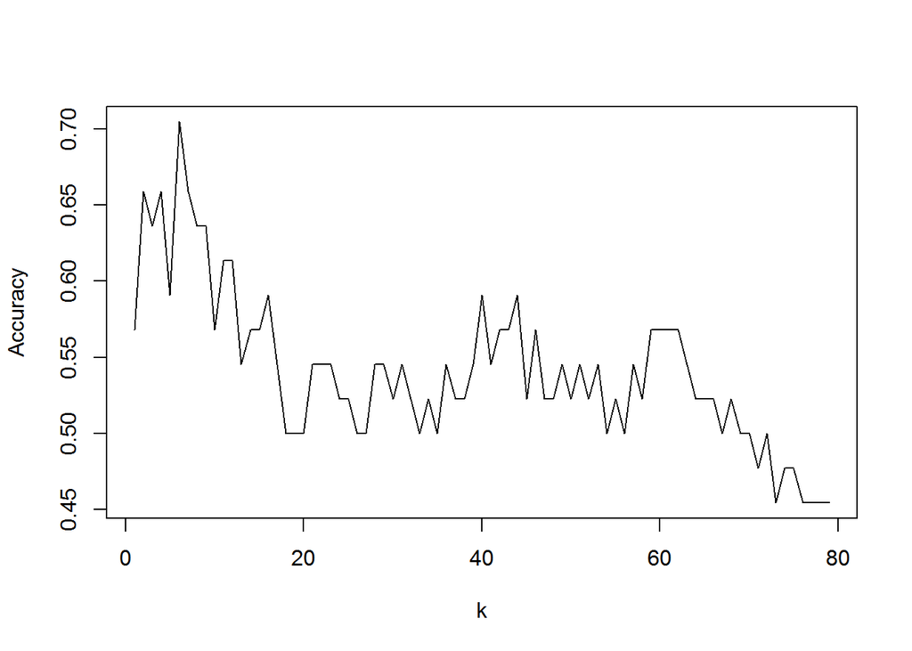

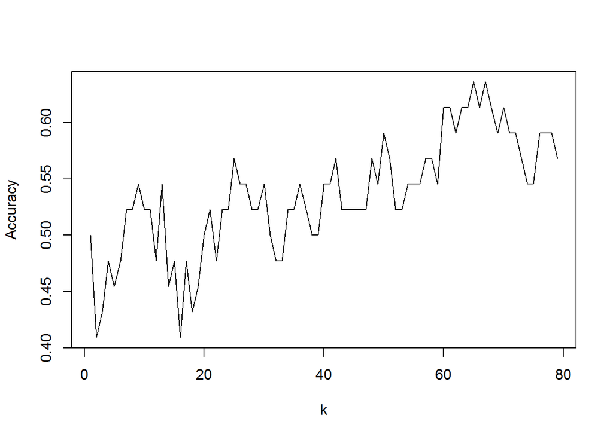

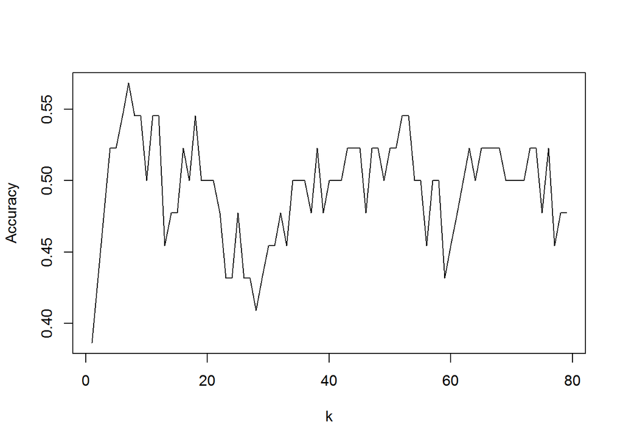

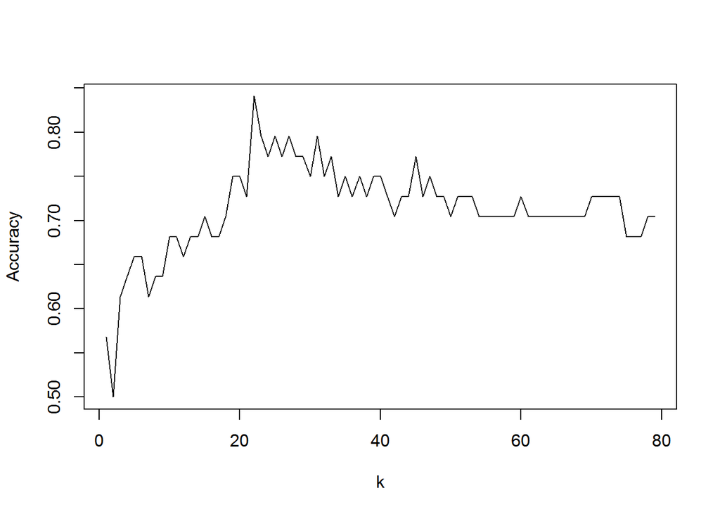

```r
m <- nrow(songs)
shuffled <- songs[sample(m),]
set.seed(1)
accs <- rep(0,10)
for(i in 1:10){
indices <- (((i-1) * round((1/10)*nrow(shuffled))) + 1):((i*round((1/10) * nrow(shuffled))))
train <- shuffled[-indices,]
test <- shuffled[indices,]
# Normalizing key
min_Key <- min(train$Key)
max_Key <- max(train$Key)
train$Key <- (train$Key - min_Key) / (max_Key - min_Key)
test$Key <- (test$Key - min_Key) / (max_Key - min_Key)

# Normalizing Loudness
min_Loud <- min(train$Loudness)
max_Loud <- max(train$Loudness)
train$Loudness <- (train$Loudness - min_Loud) / (max_Loud - min_Loud)
test$Loudness <- (test$Loudness - min_Loud) / (max_Loud - min_Loud)

#Normailizing Tempo
min_Tempo <- min(train$Tempo)
max_Tempo <- max(train$Tempo)
train$Tempo <- (train$Tempo - min_Tempo) / (max_Tempo - min_Tempo)
test$Tempo <- (test$Tempo - min_Tempo) / (max_Tempo - min_Tempo)

# Normailizing Duration
min_Dur <- min(train$Duration)
max_Dur <- max(train$Duration)
train$Duration <- (train$Duration - min_Dur) / (max_Dur - min_Dur)
test$Duration <- (test$Duration - min_Dur) / (max_Dur - min_Dur)

#Normalizing Time signature
min_time <- min(as.numeric(train$TimeSignature))
max_time <- max(as.numeric(train$TimeSignature))
train$TimeSignature <- (as.numeric(train$TimeSignature) - min_time) / (max_time - min_time)
test$TimeSignature <- (as.numeric(test$TimeSignature) - min_time) / (max_time - min_time)

train_labels <- as.factor(train[,5])
test_labels <- as.factor(test[,5])

knn_train <- train
knn_test <- test

knn_train$Successfulness <- NULL
knn_test$Successfulness <- NULL

range <- 1:round(0.2 * nrow(knn_train))
accsk <- rep(0, length(range))
for (k in range) {
        predk <- knn(train = knn_train[,c(8:18,24,25)], test = knn_test[,c(8:18,24,25)], cl = train_labels, k = k)
        confk <- table(test_labels,predk)
        accsk[k] <- sum(diag(confk))/sum(confk)

}

plot(range, accsk, xlab = "k",ylab="Accuracy",type='l')
pred <- knn(train=knn_train[,c(8:18,24,25)], test = knn_test[,c(8:18,24,25)], cl = train_labels,k=which.max(accsk))
conf <- table(test_labels,pred)
accs[i] <- sum(diag(conf))/sum(conf)
mean_acc <- mean(accs)
}
```

```r
mean_acc
```

```
## [1] 0.6863636
```

## Naive Bayes

Naive Bayes is based on Bayes Theorem which denotes that the probability of one set is based on the conditional probablity of another set. Naive Bayes comes with strong independence assumptions. Here the probability of succesfulness of the songs, whether it is successful or unsuccessful is based on the conditional probablities of audio features such as Danceabiltiy, Energy, Valence etc. Here the ROC curve denotes the true positive rates against false positive rates.

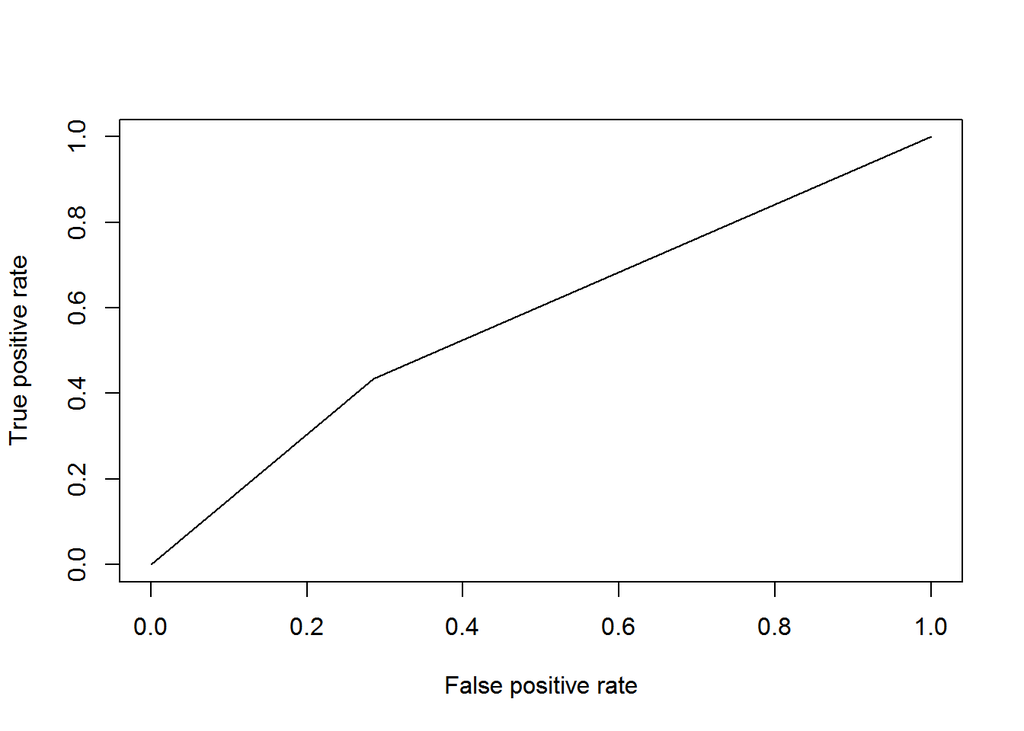

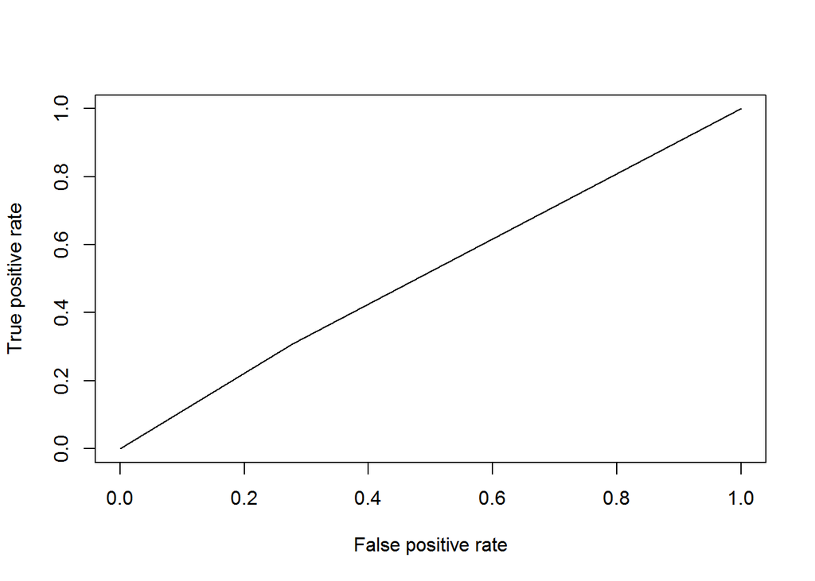

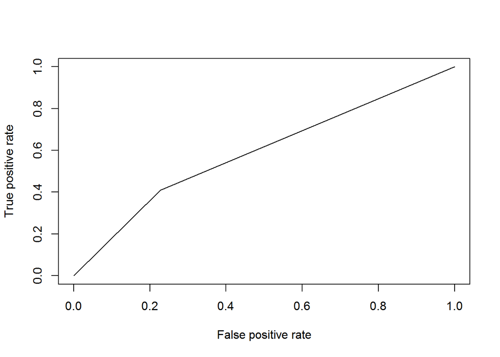

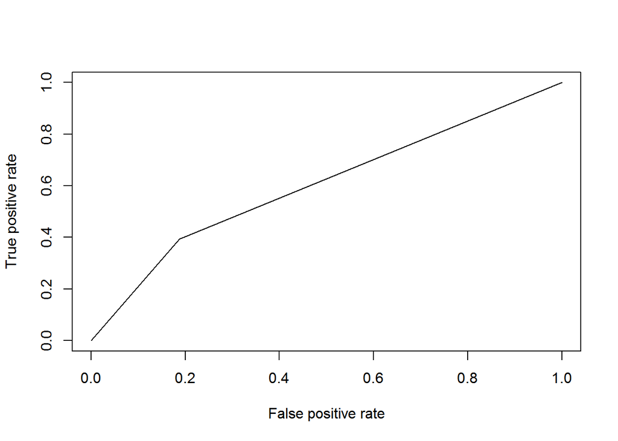

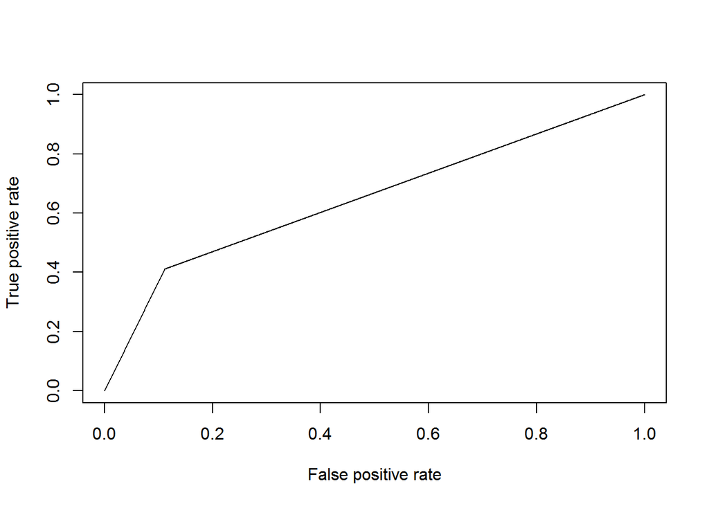

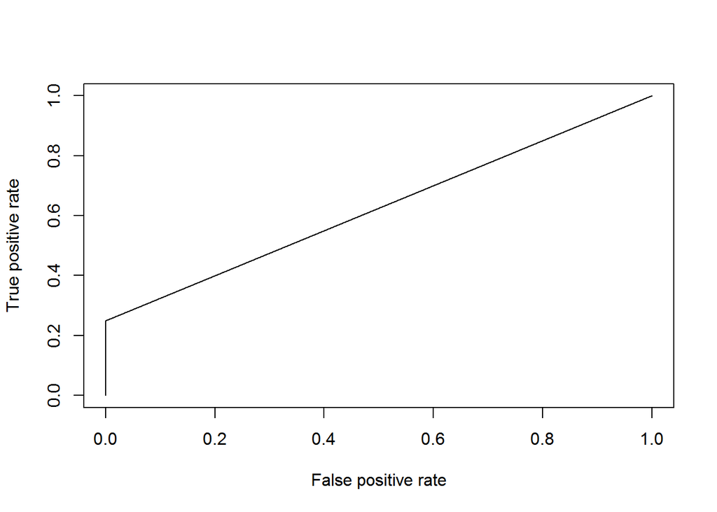

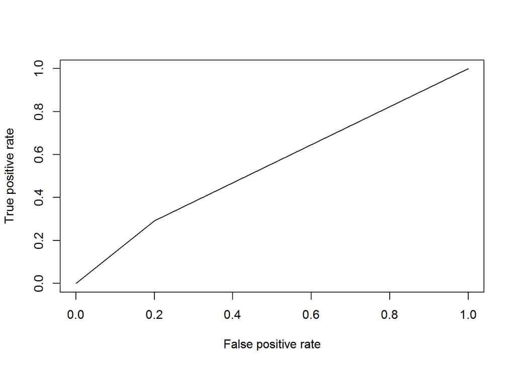

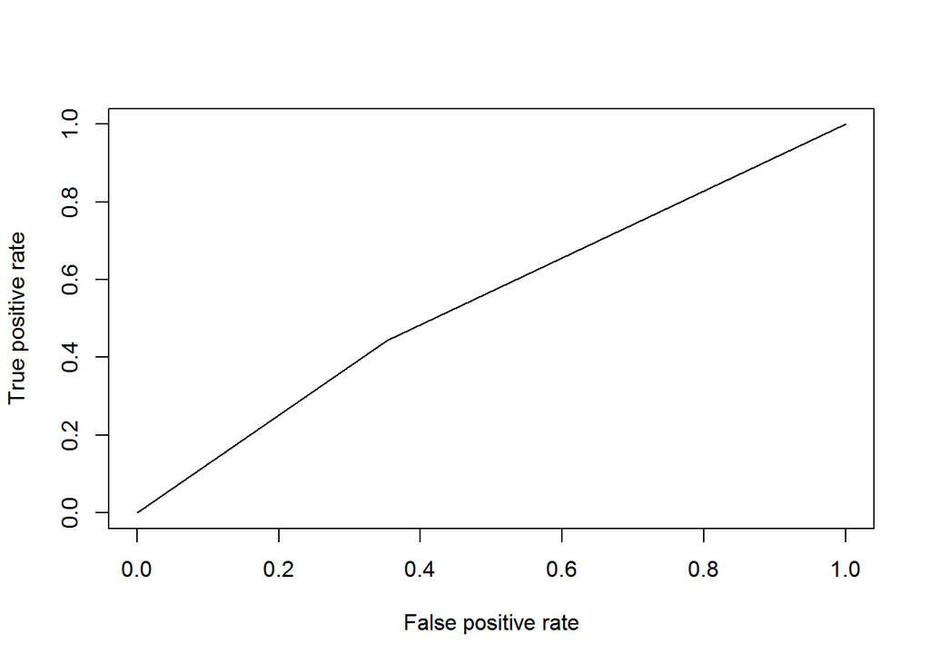

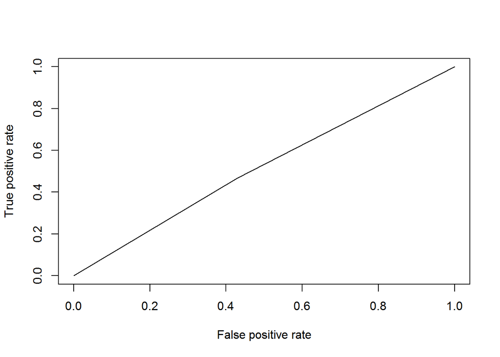

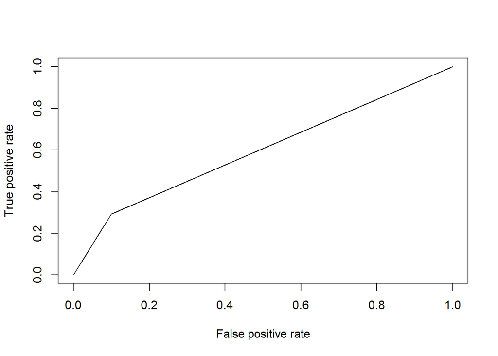

```
## [1] 0.5522727
```

```r
nb <- function(y){
       p <- nrow(songs)
shuffled <- songs[sample(p),]
set.seed(1)
accs <- rep(0,y)
for (i in 1:y)
{
        indices <- (((i-1) * round((1/y)*nrow(shuffled))) + 1):((i*round((1/y) * nrow(shuffled))))
        train <- shuffled[-indices,]
        test <- shuffled[indices,]
# Normalizing key
min_Key <- min(train$Key)
max_Key <- max(train$Key)
train$Key <- (train$Key - min_Key) / (max_Key - min_Key)
test$Key <- (test$Key - min_Key) / (max_Key - min_Key)

# Normalizing Loudness
min_Loud <- min(train$Loudness)
max_Loud <- max(train$Loudness)
train$Loudness <- (train$Loudness - min_Loud) / (max_Loud - min_Loud)
test$Loudness <- (test$Loudness - min_Loud) / (max_Loud - min_Loud)

#Normailizing Tempo
min_Tempo <- min(train$Tempo)
max_Tempo <- max(train$Tempo)
train$Tempo <- (train$Tempo - min_Tempo) / (max_Tempo - min_Tempo)
test$Tempo <- (test$Tempo - min_Tempo) / (max_Tempo - min_Tempo)

# Normailizing Duration
min_Dur <- min(train$Duration)
max_Dur <- max(train$Duration)
train$Duration <- (train$Duration - min_Dur) / (max_Dur - min_Dur)
test$Duration <- (test$Duration - min_Dur) / (max_Dur - min_Dur)

#Normalizing Time signature
min_time <- min(as.numeric(train$TimeSignature))
max_time <- max(as.numeric(train$TimeSignature))
train$TimeSignature <- (as.numeric(train$TimeSignature) - min_time) / (max_time - min_time)
test$TimeSignature <- (as.numeric(test$TimeSignature) - min_time) / (max_time - min_time)

nb_model <- naiveBayes(Successfulness ~ Danceability+Energy+Key+Loudness+Mode+Speechiness+Acousticness+Instrumentalness+Liveliness+Valence+Tempo+Duration+TimeSignature, train)
pred <- predict(nb_model,test)
conf <- table(test$Successfulness,pred)
accs[i] <- sum(diag(conf))/sum(conf)

# ROC Curve
nb.pred <- prediction(as.numeric(pred), as.numeric(test$Successfulness))
nb.roc.perf <- performance(nb.pred, "tpr", "fpr")
plot(nb.roc.perf,xlab="False positive rate",ylab="True positive rate")
}
mean(accs)
}
nb(10)
```